# Da matriz de contagens à biologia: um olhar estatístico

## Consequências do *double dipping*

- Os valores-p de `FindMarkers()` **não são** valores-p válidos de teste de hipótese: são escores para **ordenar** genes.
- Em dados reais o efeito é maior: o agrupamento procura justamente as direções de maior diferença.
- Soluções em desenvolvimento:
  - **inferência seletiva**: condiciona o teste ao evento “o algoritmo produziu estes grupos”;
  - **divisão de contagens** (*count splitting*): $Y = Y^{(1)} + Y^{(2)}$ por amostragem binomial; agrupa com $Y^{(1)}$, testa com $Y^{(2)}$.

Gao, Bien & Witten, *JASA*, 2024 · Neufeld et al., *Biostatistics*, 2024

## Problema 2: pseudorreplicação

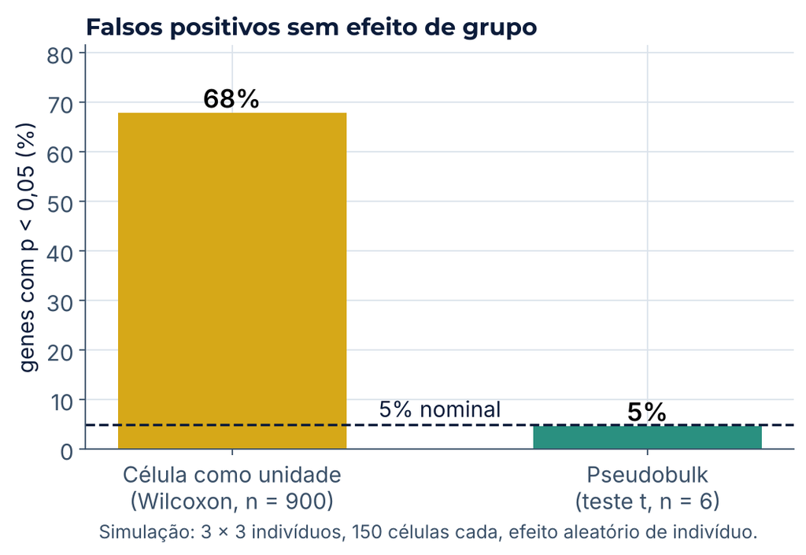

- Para comparar **condições** (COVID grave × leve), a unidade é o indivíduo.
- Tratar milhares de células como independentes infla o tamanho amostral: o teste ignora a variância entre indivíduos.
- **Pseudobulk**: some as contagens por indivíduo e tipo celular. Analise com `edgeR`, `DESeq2` ou `limma`.
- Alternativa: modelo misto com efeito aleatório de indivíduo.

Squair et al., *Nature Communications*, 2021

# Análise funcional

PARTE 7

≈ 10 min · notebook: encontro 2, bloco B12

## De uma lista de genes a uma história biológica

- Depois da DE temos **listas longas** de genes; ninguém interpreta 5.000 nomes um a um.
- Bancos de anotação agrupam genes por função conhecida: **Gene Ontology** (GO), KEGG, Reactome.
- Pergunta: algum conjunto de genes aparece na lista **mais do que o acaso explicaria**?

Esta é a forma mais simples, chamada **análise de super-representação** (ORA). Ela só usa a lista, não os valores de cada gene.

## A Gene Ontology

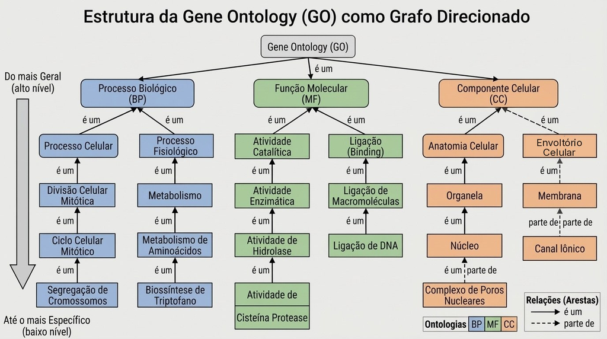

Três ontologias: processo biológico (BP), função molecular (MF) e componente celular (CC). Termos formam um grafo: um gene anotado num termo específico pertence também aos termos acima.

## A tabela 2 × 2 de cada termo

Na C141: 5.084 genes da lista com anotação GO (marcadores com $|\log_2 FC| > 1$ e $p_{\text{adj}}$ < 0,1), num universo de 18.842 genes anotados.

|  | No termo “cilium organization” | Fora do termo | Total |
| --- | --- | --- | --- |
| Na lista | **249** | 4.835 | 5.084 |
| Fora da lista | 173 | 13.585 | 13.758 |
| Total | 422 | 18.420 | 18.842 |

Sob $H_0$ (a lista é uma amostra aleatória do universo), o número de genes do termo na lista segue uma **hipergeométrica**.

Saída da célula 222 do Módulo 04 · `enrichGO()`: GeneRatio 249/5084, BgRatio 422/18842

## O teste hipergeométrico

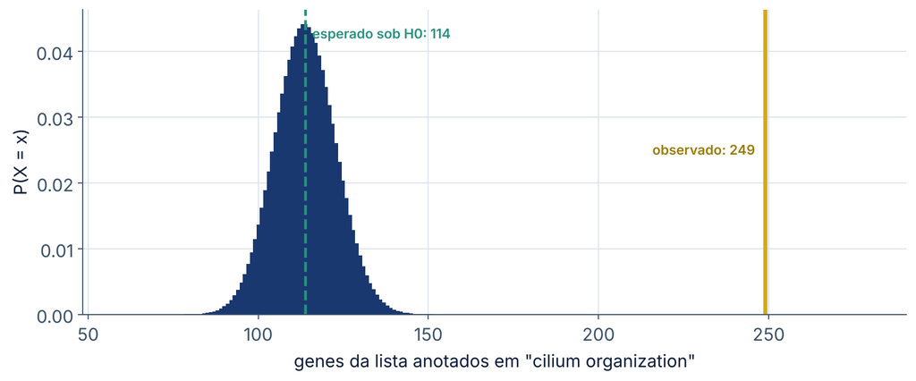

$$P(X \ge k) = \sum_{x \ge k} \frac{\binom{K}{x}\binom{N - K}{n - x}}{\binom{N}{n}}$$

- $N$ = 18.842, $K$ = 422, $n$ = 5.084, $k$ = 249
- Esperado: $nK/N$ = 113,9 (DP 9,0)
- Razão: 249 / 113,9 = 2,19
- $P(X \ge 249) \approx 2 \times 10^{-44}$
- Equivale ao teste exato de Fisher unilateral.

## Múltiplos testes e cuidados

- O `enrichGO()` testa milhares de termos: correção de **Benjamini-Hochberg** (FDR). Na C141, **649 termos** de BP passaram.
- Termos são **dependentes**: genes compartilhados e hierarquia geram listas redundantes.
- **O universo importa:** use os genes **testados**, não o genoma inteiro. Universo grande demais infla o enriquecimento.
- **A lista importa:** aqui ela junta marcadores de 11 grupos. Melhor uma análise por grupo.
- Sem limiar: **GSEA** usa a lista inteira ordenada e testa se o termo se concentra no topo.

“Cilium organization” no topo reflete as células ciliadas (grupo 7), não uma resposta à COVID-19.

# Fechamento

RESUMO

≈ 3 min

## As decisões do analista

| Etapa | Decisão | Valor usado na C141 | O que muda se alterar |
| --- | --- | --- | --- |
| QC | limiares de UMI, genes e % MT | 500 · 7.000 · 10% | quais células existem |
| Normalização | LogNormalize ou SCTransform | ambos (RNA e SCT) | variância dos genes |
| HVG | número de genes | 2.000 | o espaço da PCA |
| PCA | número de componentes | 15 (UMAP) · 20 (grafo) | vizinhanças |
| Grafo | número de vizinhos $k$ | 20 (padrão) | conectividade |
| Agrupamento | resolução $\gamma$ | 0,01 · 0,2 · 0,8 | número de grupos |
| DE | teste, filtros, contraste | Wilcoxon, `min.pct` 0,25 | lista de genes |
| Enriquecimento | lista, universo, banco | 5.084 · 18.842 · GO BP | termos significativos |

## Para levar

- A célula é a observação para **descrever populações**; o indivíduo é a unidade para **comparar condições**.
- Quase toda etapa tem um parâmetro escolhido pelo analista: registre, varie e reporte a sensibilidade.
- UMAP é para **ver**, não para medir.
- Valores-p de marcadores **ordenam** genes; não confirmam que os grupos existem.
- Enriquecimento depende da lista e do universo tanto quanto do teste.

## Material para estudo

- **Notebooks** dos encontros 1 e 2 no Colab, com todo o código mostrado hoje e os pontos de resgate CP0 a CP5.
- **Slides completos** dos dois encontros, bloco a bloco, com a prática guiada.
- Página do minicurso: [benilton.github.io/minicurso-rbras-2026](https://benilton.github.io/minicurso-rbras-2026/)

Rojas-Hidalgo A, Arias-Carrasco R, Silva JK, et al. The Single Cell Notebooks for inclusive and accessible training in single-cell and spatial omics. *Nature Genetics* 58, 1189-1194 (2026).

DOI: 10.1038/s41588-026-02584-0

## Leituras sugeridas

- Liao M et al. Single-cell landscape of bronchoalveolar immune cells in patients with COVID-19. *Nature Medicine*, 2020.
- Hafemeister C, Satija R. Normalization and variance stabilization of single-cell RNA-seq data using regularized negative binomial regression. *Genome Biology*, 2019.
- Germain PL et al. Doublet identification in single-cell sequencing data using scDblFinder. *F1000Research*, 2021.
- McInnes L, Healy J, Melville J. UMAP: uniform manifold approximation and projection for dimension reduction. *arXiv*, 2018.
- Chari T, Pachter L. The specious art of single-cell genomics. *PLoS Computational Biology*, 2023.
- Gao LL, Bien J, Witten D. Selective inference for hierarchical clustering. *Journal of the American Statistical Association*, 2024.
- Neufeld A et al. Inference after latent variable estimation for single-cell RNA sequencing data. *Biostatistics*, 2024.
- Squair JW et al. Confronting false discoveries in single-cell differential expression. *Nature Communications*, 2021.
- Heumos L et al. Best practices for single-cell analysis across modalities. *Nature Reviews Genetics*, 2023.